# Viabilidad 15

límite de 3 operarios, ingresos de 35 k€/mes durante 60 meses

# Enunciado

Una empresa va a ejecutar el proyecto de inversión cuyo cuadro de prelaciones, duración (meses), operarios necesarios y presupuesto (BAC, k€) de cada actividad se adjunta. El coste de cada actividad se desembolsa uniformemente a lo largo de su duración. Cuando el proyecto termina, la instalación genera un flujo de caja neto de 35 k€ al mes durante 60 meses. La empresa descuenta al 10% anual y dispone como máximo de **3 operarios** al mes. Contratar un operario más cuesta **1.0 k€ por mes** mientras dure el proyecto.

1. Calcule la duración y el VAN del proyecto sin tener en cuenta el límite de operarios.

2. Aplique el algoritmo de asignación con el límite de operarios. ¿Cuánto se alarga el proyecto y cuánto cuesta en VAN? Separe el efecto sobre el VAN de los costes y el de los ingresos y explique cuál domina.

3. ¿Compensa contratar un operario más (límite 4)? Construya la tabla de duración y VAN al ampliar el límite en 0, 1, 2 y 3 operarios y compare la mejora del VAN con el coste de contratar (sin descontar, por simplicidad).

4. Calcule el flujo mensual mínimo (umbral del VAN = 0) con y sin el límite. ¿Cuánto sube el umbral por culpa del límite?

Tabla 1: Datos del proyecto

| activity | predecessor | duration | operarios | BAC |
| --- | --- | --- | --- | --- |
| A | --- | 1 | 1 | 75 |
| B | --- | 2 | 2 | 100 |
| C | --- | 6 | 1 | 200 |
| D | A,B | 8 | 2 | 75 |
| E | C,D | 4 | 1 | 150 |
| F | E | 4 | 2 | 100 |
| G | E | 3 | 2 | 175 |
| H | F,G | 4 | 3 | 75 |
| I | H | 1 | 2 | 175 |

# Resolución

## Apartado 1

1. Calcule la duración y el VAN del proyecto sin tener en cuenta el límite de operarios.

Cálculo de los tiempos mínimos y máximos de los nodos del grafo Roy paso a paso. El primer paso muestra el grafo resuelto; a partir del siguiente se calcula desde el principio (avance con los botones):

[figure not shown]

paso 0 de 24

[figure not shown]

Figura 1: Grafo Roy con el camino crítico (sin límite de operarios)

Tabla 2: Calendario sin límite de recursos (meses)

[figure not shown]

ninguna celda (0 de 72)

[figure not shown]

Haz clic en un número de la tabla para ver cómo se calcula.

👆 **Interactivo:** haz clic en cualquier celda de la tabla para ver cómo se calcula (otro clic la deselecciona), o usa los botones y las flechas del teclado.

| Actividad | Duración | Inicio más temprano | Fin más temprano | Inicio más tardío | Fin más tardío | H total | H libre | H independiente |
| --- | --- | --- | --- | --- | --- | --- | --- | --- |
| A | 1 | 0 | 1 | 1 | 2 | 1 | 1 | 1 |
| B | 2 | 0 | 2 | 0 | 2 | 0 | 0 | 0 |
| C | 6 | 0 | 6 | 4 | 10 | 4 | 4 | 4 |
| D | 8 | 2 | 10 | 2 | 10 | 0 | 0 | 0 |
| E | 4 | 10 | 14 | 10 | 14 | 0 | 0 | 0 |
| F | 4 | 14 | 18 | 14 | 18 | 0 | 0 | 0 |
| G | 3 | 14 | 17 | 15 | 18 | 1 | 1 | 1 |
| H | 4 | 18 | 22 | 18 | 22 | 0 | 0 | 0 |
| I | 1 | 22 | 23 | 22 | 23 | 0 | 0 | 0 |

El coste mensual de cada actividad es su BAC entre su duración; la fila *Total* del Gantt es el desembolso de cada mes. Cada mes es un periodo: en los meses 1…T el flujo es −desembolso y en los T+1…T+N, +F; la tasa mensual equivalente cumple $(1 + k_m)^{12} = 1 + k$.

[figure not shown]

Figura 2: Gantt de inicios más tempranos con el coste mensual de cada actividad (k€)

|  | 1 | 2 | 3 | 4 | 5 | 6 | 7 | 8 | 9 | 10 | 11 | 12 | 13 | 14 | 15 | 16 | 17 | 18 | 19 | 20 | 21 | 22 | 23 |
| --- | --- | --- | --- | --- | --- | --- | --- | --- | --- | --- | --- | --- | --- | --- | --- | --- | --- | --- | --- | --- | --- | --- | --- |
| desembolso (k€) | 158.3 | 83.3 | 42.7 | 42.7 | 42.7 | 42.7 | 9.4 | 9.4 | 9.4 | 9.4 | 37.5 | 37.5 | 37.5 | 37.5 | 83.3 | 83.3 | 83.3 | 25.0 | 18.8 | 18.8 | 18.8 | 18.8 | 175.0 |

k mensual = (1 + 0.1)^(1/12) − 1 = 0.7974%. Sin límite: 23 meses de inversión (1125 k€ = Σ BAC).

- VA de los desembolsos = Σ desembolso_m/(1 + k_m)^m = 158.3/1.00797¹ + 83.3/1.00797² + 42.7/1.00797³ + … + 175.0/1.00797²³ = **1026.2 k€**.

- VA de los ingresos: renta de N = 60 meses de 35.0 k€ que empieza en el mes T + 1 = 24: F · [1 − (1 + k_m)^−N]/k_m · (1 + k_m)^−T = 35.0 × [1 − 1.00797^−60]/0.007974 × 1.00797^−23 = 35.0 × 47.539 × 0.8330 = **1386.0 k€**.

- VAN = 1386.0 − 1026.2 = **359.9 k€**.

**Respuesta:** sin límite de operarios el proyecto dura 23 meses y su VAN es 359.9 k€.

Tabla 3: VAN sin y con límite de operarios (van_recursos)

| escenario | duración | VAN costes | VAN ingresos | VAN |
| --- | --- | --- | --- | --- |
| sin límite | 23.0 | 1026.18 | 1386.05 | 359.87 |
| con límite | 26.0 | 1014.89 | 1353.41 | 338.52 |

La librería da lo mismo: sin límite 23 meses y VAN 359.9 k€ (VAN de los ingresos 1386.0, de los costes 1026.2).

## Apartado 2

2. Aplique el algoritmo de asignación con el límite de operarios. ¿Cuánto se alarga el proyecto y cuánto cuesta en VAN? Separe el efecto sobre el VAN de los costes y el de los ingresos y explique cuál domina.

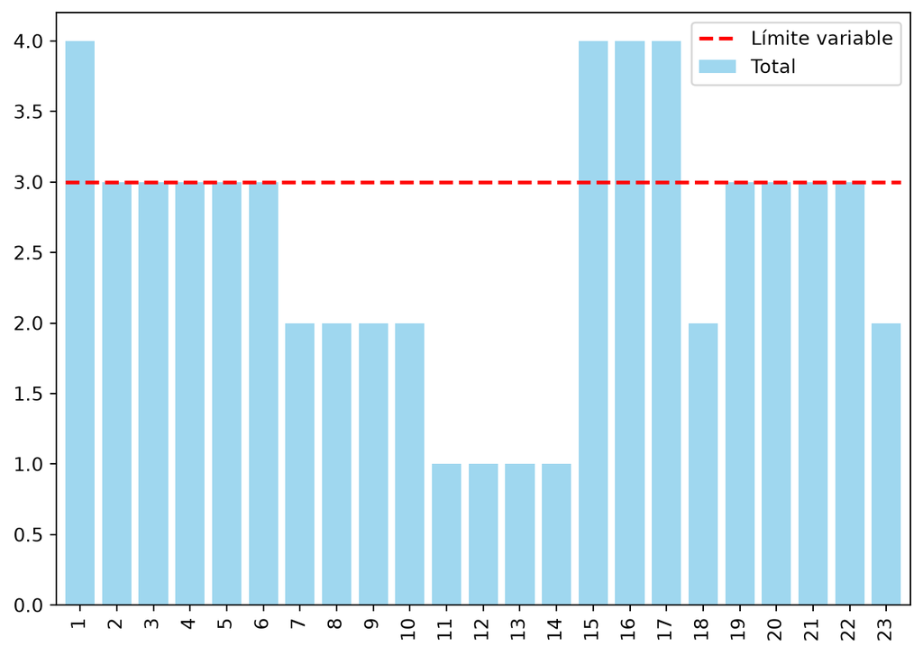

Figura 3: Carga de operarios con los inicios más tempranos frente al límite

El algoritmo de asignación recorre los meses; cada actividad disponible (predecesoras terminadas) empieza, por orden de prioridad (menor inicio más tardío), si caben sus operarios durante toda su duración; si no, espera. Traza mes a mes y Gantt resultante (filas 💤: esperas):

Periodo 1. Empiezan: [‘B’, ‘A’]. Esperan: [‘C (operarios)’]

Periodo 2. Empiezan: [‘C’]. Esperan: []

Periodo 3. Empiezan: [‘D’]. Esperan: []

Periodo 11. Empiezan: [‘E’]. Esperan: []

Periodo 15. Empiezan: [‘F’]. Esperan: [‘G (operarios)’]

Periodo 16. Empiezan: []. Esperan: [‘G (operarios)’]

Periodo 17. Empiezan: []. Esperan: [‘G (operarios)’]

Periodo 18. Empiezan: []. Esperan: [‘G (operarios)’]

Periodo 19. Empiezan: [‘G’]. Esperan: []

Periodo 22. Empiezan: [‘H’]. Esperan: []

Periodo 26. Empiezan: [‘I’]. Esperan: []

[figure not shown]

Figura 4: Gantt con el límite de operarios

Tabla 4: Inicio de cada actividad sin y con límite

| activity | A | B | C | D | E | F | G | H | I |
| --- | --- | --- | --- | --- | --- | --- | --- | --- | --- |
| inicio sin límite | 0 | 0 | 0 | 2 | 10 | 14 | 14 | 18 | 22 |
| inicio con límite | 0 | 0 | 1 | 2 | 10 | 14 | 18 | 21 | 25 |
| espera (meses) | 0 | 0 | 1 | 0 | 0 | 0 | 4 | 0 | 0 |

Tabla 5: Desembolso mensual sin y con límite (k€)

|  | 1 | 2 | 3 | 4 | 5 | 6 | 7 | 8 | 9 | 10 | 11 | 12 | 13 | 14 | 15 | 16 | 17 | 18 | 19 | 20 | 21 | 22 | 23 | 24 | 25 | 26 |
| --- | --- | --- | --- | --- | --- | --- | --- | --- | --- | --- | --- | --- | --- | --- | --- | --- | --- | --- | --- | --- | --- | --- | --- | --- | --- | --- |
| sin límite | 158.3 | 83.3 | 42.7 | 42.7 | 42.7 | 42.7 | 9.4 | 9.4 | 9.4 | 9.4 | 37.5 | 37.5 | 37.5 | 37.5 | 83.3 | 83.3 | 83.3 | 25.0 | 18.8 | 18.8 | 18.8 | 18.8 | 175.0 | 0.0 | 0.0 | 0.0 |
| con límite | 125.0 | 83.3 | 42.7 | 42.7 | 42.7 | 42.7 | 42.7 | 9.4 | 9.4 | 9.4 | 37.5 | 37.5 | 37.5 | 37.5 | 25.0 | 25.0 | 25.0 | 25.0 | 58.3 | 58.3 | 58.3 | 18.8 | 18.8 | 18.8 | 18.8 | 175.0 |

Con 3 operarios el proyecto dura 26 meses (+3): los ingresos empiezan en el mes 27 en vez del 24. VAN = 338.5 k€ (la librería: 338.5) frente a 359.9 sin límite: -21.4 k€. Efecto en los ingresos: -32.6 k€ (se cobran más tarde); en los costes: 11.3 k€ (las actividades que esperan se pagan más tarde y el coste se descuenta más). Los ingresos son la misma renta desplazada 3 meses: VA = 1386.0 × 1.00797^−3 = 1353.4 k€. **Respuesta:** el proyecto se alarga 3 meses y pierde 21.4 k€ de VAN; domina el retraso de los ingresos (-32.6 k€ frente a +11.3 k€ de ahorro en costes).

## Apartado 3

3. ¿Compensa contratar un operario más (límite 4)? Construya la tabla de duración y VAN al ampliar el límite en 0, 1, 2 y 3 operarios y compare la mejora del VAN con el coste de contratar (sin descontar, por simplicidad).

Tabla 6: Duración y VAN al ampliar el límite de operarios

| unidades de más | duración | VAN | mejora de VAN | coste de contratar | coste = operarios × coste mensual × duración | VAN neto de contratar |
| --- | --- | --- | --- | --- | --- | --- |
| 0 | 26.0 | 338.52 | NaN | 0.0 | 0 × 1 × 26 = 0.0 | 338.52 |
| 1 | 23.0 | 359.87 | 21.34 | 23.0 | 1 × 1 × 23 = 23.0 | 336.87 |
| 2 | 23.0 | 359.87 | 0.00 | 46.0 | 2 × 1 × 23 = 46.0 | 313.87 |
| 3 | 23.0 | 359.87 | 0.00 | 69.0 | 3 × 1 × 23 = 69.0 | 290.87 |

Un operario más mejora el VAN en 359.9 − 338.5 = 21.3 k€ y cuesta 23.0 k€: no compensa. **Respuesta:** la mejor opción es no ampliar el límite (VAN 338.5 k€): ninguna ampliación tiene un VAN neto mayor. Se compara la mejora del VAN por adelantar los ingresos con lo que cuesta mantener a los operarios todo el proyecto; con más de 1 operario extra el proyecto ya no se acorta y sólo se suma coste.

## Apartado 4

4. Calcule el flujo mensual mínimo (umbral del VAN = 0) con y sin el límite. ¿Cuánto sube el umbral por culpa del límite?

El VAN es lineal en el flujo mensual: VAN(F) = −VA desembolsos + F · VA de una renta de 1 k€/mes durante N meses desde el mes T + 1. Por tanto el umbral es F* = VA desembolsos / VA de la renta unitaria: sin límite: 1026.2/39.601 = 25.91 k€/mes; con límite: 1014.9/38.669 = 26.25 k€/mes. **Respuesta:** flujo mensual mínimo 25.91 k€ sin límite y 26.25 k€ con límite; el límite lo sube 0.33 k€ al mes: al retrasar los ingresos, hacen falta más para recuperar la inversión.